# BIS 15L Project

2024-02-29

## Load the libraries

```r
library(tidyverse)
library(janitor)
```

## Install and load the `ggmap` package

```r
#install.packages("ggmap")
library(ggmap)
```

## R Markdown

```r
Eliminations<- read.csv("data/eliminations_and_dates.csv") %>% clean_names()
```

```r
Hometown<- read.csv("data/hometown_coordinates.csv") %>% clean_names()
```

```r
Seasons<- read.csv("data/season_details.csv") %>% clean_names()
```

```r
Contestants <- read.csv("data/contestant_details.csv") %>% clean_names()
```

```r
Compact_eliminations <- read.csv("data/eliminations_and_dates_compact.csv") %>% clean_names()
```

## what is the most popular name of the contestants

```r
Contestants %>%
  separate(full_name, c("first_name", "last_name"), sep = " ") %>%
  group_by(first_name) %>%
  filter(show=="Bachelor") %>%
  summarise(count = n()) %>%
  arrange(desc(count))
```

```
## # A tibble: 388 × 2
##    first_name count
##    <chr>      <int>
##  1 Lauren        17
##  2 Sarah         12
##  3 Amber         11
##  4 Ashley        10
##  5 Amanda         9
##  6 Jessica        9
##  7 Heather        8
##  8 Amy            7
##  9 Elizabeth      7
## 10 Erin           7
## # ℹ 378 more rows
```

```r
Contestants %>%
  separate(full_name, c("first_name", "last_name"), sep = " ") %>%
  group_by(first_name) %>%
  filter(show=="Bachelorette") %>%
  summarise(count = n()) %>%
  arrange(desc(count))
```

```
## # A tibble: 226 × 2
##    first_name count
##    <chr>      <int>
##  1 Chris         15
##  2 Ryan          14
##  3 Brian         11
##  4 Nick           9
##  5 John           8
##  6 Ben            7
##  7 Jonathan       7
##  8 Michael        7
##  9 Blake          6
## 10 Eric           6
## # ℹ 216 more rows
```

## what is the maximun and minimum age of the contestants?

```r
Contestants %>%
  summarise(max_age = max(age, na.rm = TRUE),
            min_age = min(age, na.rm = TRUE))
```

```
##   max_age min_age
## 1      42      21
```

##1 What is the average age of the contestants?

```r
Contestants %>%
  summarise(mean_age = mean(age, na.rm = TRUE))
```

```
##   mean_age
## 1 27.50409
```

## what is the average age of the contestants by season?

```r
Contestants %>%
  group_by(season) %>%
  summarise(mean_age = mean(age, na.rm = TRUE))
```

```
## # A tibble: 25 × 2
##    season mean_age
##     <int>    <dbl>
##  1      1     28.1
##  2      2     28.1
##  3      3     27.3
##  4      4     27.8
##  5      5     26.9
##  6      6     30.0
##  7      7     27.7
##  8      8     28.1
##  9      9     27.5
## 10     10     27.6
## # ℹ 15 more rows
```

how many seasons of the bachelor and bachelorette are there?

```r
Seasons %>%
  group_by(show) %>%
  summarise(count = n())
```

```
## # A tibble: 2 × 2
##   show         count
##   <chr>        <int>
## 1 Bachelor        24
## 2 Bachelorette    17
```

##Use a geom _col plot to compare the average age of the contestants between the two shows

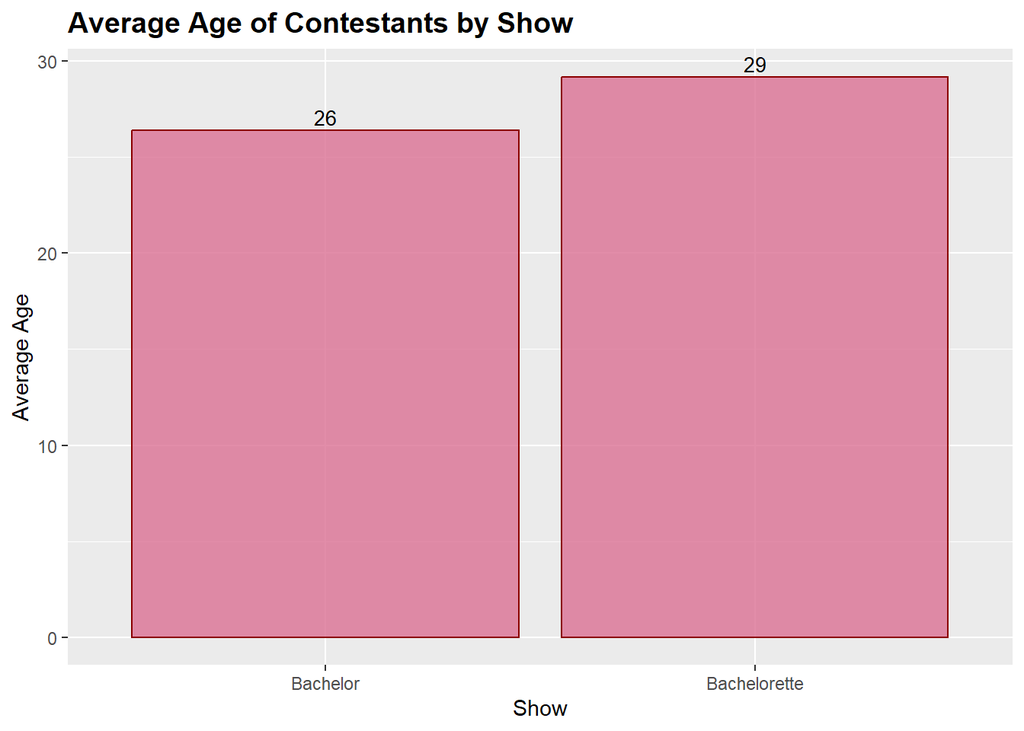

```r
Contestants %>%
  group_by(show) %>%
  summarise(mean_age = mean(age, na.rm = TRUE)) %>%
  ggplot(aes(x = show, y = mean_age, fill = show)) +
  geom_col(fill="palevioletred", color="darkred", alpha=0.8) +
  labs(title = "Average Age of Contestants by Show",
       x = "Show",
       y = "Average Age",
       fill = "Show")+
  theme(plot.title = element_text(size=14, face="bold"))+
geom_text(aes(label=round(mean_age)), vjust=-0.3, size=3.5)
```

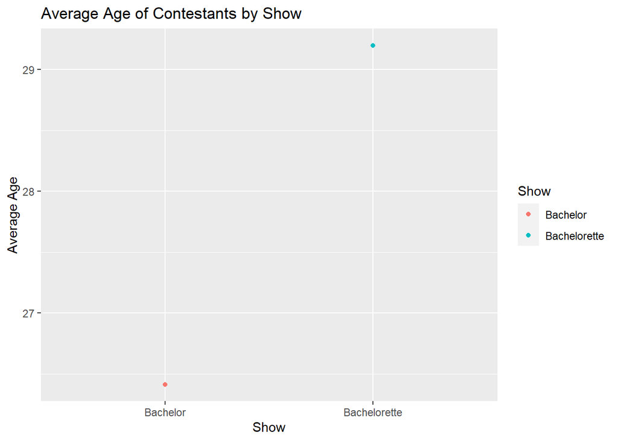

```r
Contestants %>%
  group_by(show) %>%
  summarise(mean_age = mean(age, na.rm = TRUE)) %>%
  ggplot(aes(x = show, y = mean_age, color = show)) +
  geom_point() +
  labs(title = "Average Age of Contestants by Show",
       x = "Show",
       y = "Average Age",
       color = "Show")
```

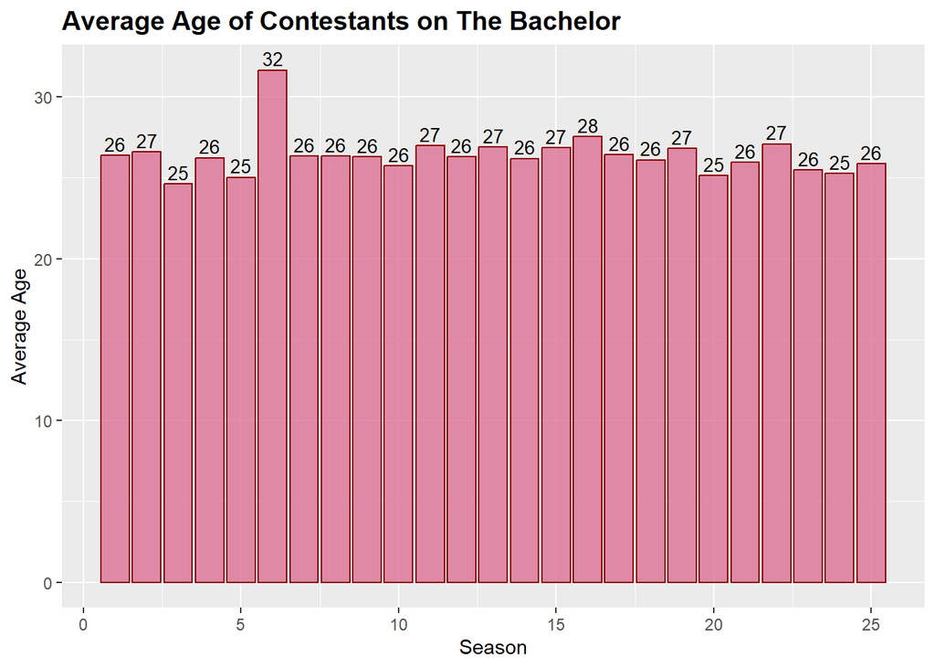

```r
Contestants %>%
  group_by(season) %>%
  filter(show=="Bachelor") %>%
  summarise(mean_age = mean(age, na.rm = TRUE)) %>%
  ggplot(aes(x = season, y = mean_age)) +
  geom_col(fill="palevioletred", color="darkred", alpha=0.8) +
  labs(title = "Average Age of Contestants on The Bachelor",
       x = "Season",
       y = "Average Age")+
  theme(plot.title = element_text(size=14, face="bold"))+
  geom_text(aes(label=round(mean_age)), vjust=-0.3, size=3.5)
```

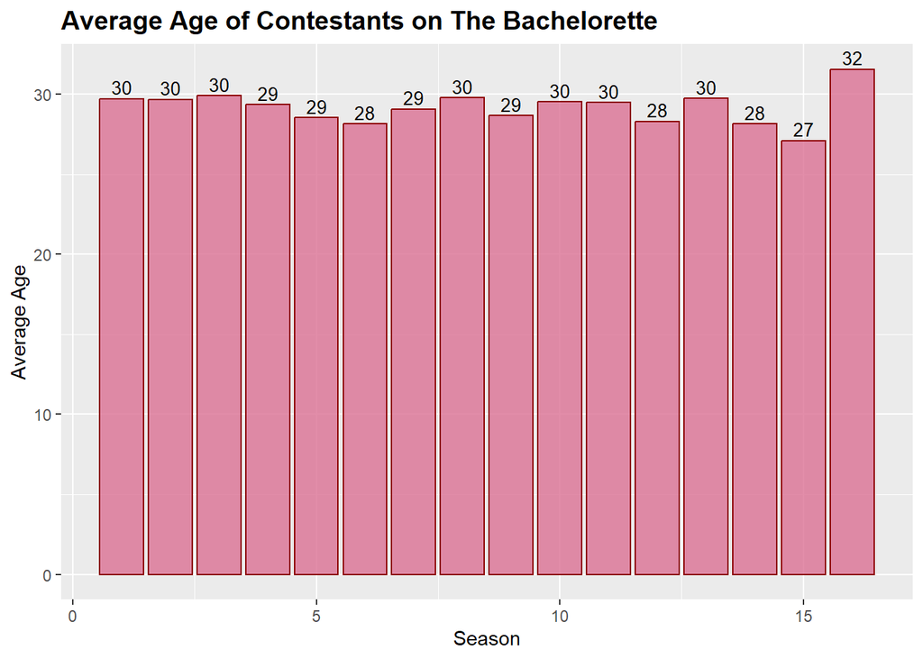

```r
Contestants %>%
  group_by(season) %>%
  filter(show=="Bachelorette") %>%
  summarise(mean_age = mean(age, na.rm = TRUE)) %>%
  ggplot(aes(x = season, y = mean_age)) +
  geom_col(fill="palevioletred", color="darkred", alpha=0.8) +
  labs(title = "Average Age of Contestants on The Bachelorette",
       x = "Season",
       y = "Average Age")+
  theme(plot.title = element_text(size=14, face="bold"))+
  geom_text(aes(label=round(mean_age)), vjust=-0.3, size=3.5)
```

#make a table of all of the occupations of the contestants

```r
Contestants %>%
  group_by(occupation) %>%
  summarise(count = n()) %>%
  arrange(desc(count))
```

```
## # A tibble: 737 × 2
##    occupation       count
##    <chr>            <int>
##  1 Attorney            21
##  2 Realtor             15
##  3 Teacher             14
##  4 Flight Attendant    13
##  5 Student             12
##  6 Lawyer              11
##  7 Bartender           10
##  8 Entrepreneur        10
##  9 Model               10
## 10 Nanny               10
## # ℹ 727 more rows
```

## make a graph that shows the trend in occupation of the contestants, make the graph pink

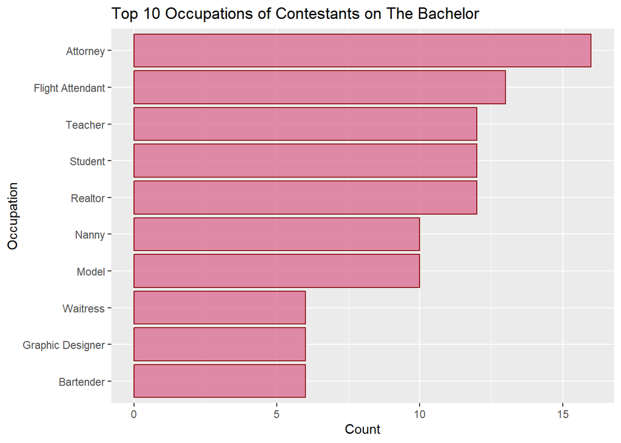

```r
Contestants %>%
  group_by(occupation) %>%
  filter(show=="Bachelor") %>%
  summarise(count = n()) %>%
  arrange(desc(count)) %>%
  top_n(10) %>%
  ggplot(aes(x = reorder(occupation, count), y = count)) +
  geom_col(fill="palevioletred", color="darkred", alpha=0.8) +
  coord_flip() +
  labs(title = "Top 10 Occupations of Contestants on The Bachelor",
       x = "Occupation",
       y = "Count")
```

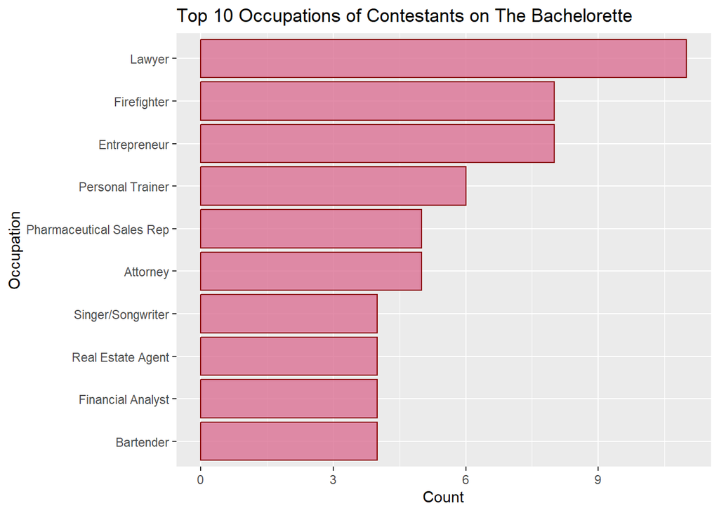

```r
Contestants %>%
  group_by(occupation) %>%
  filter(show=="Bachelorette") %>%
  summarise(count = n()) %>%
  arrange(desc(count)) %>%
  top_n(10) %>%
  ggplot(aes(x = reorder(occupation, count), y = count)) +
  geom_col(fill="palevioletred", color="darkred", alpha=0.8) +
  coord_flip() +
  labs(title = "Top 10 Occupations of Contestants on The Bachelorette",
       x = "Occupation",
       y = "Count")
```

use the season data to find the top 10 occupations of the bachelor and bachelorette canadidates by season, combine the repeating occupations

```r
Seasons %>%
  group_by(occupation) %>%
  filter(show=="Bachelor") %>%
  summarise(count = n()) %>%
  arrange(desc(count))
```

```
## # A tibble: 22 × 2
##    occupation                 count
##    <chr>                      <int>
##  1 Bar Owner                      2
##  2 Former Pro Football Player     2
##  3 Account Executive              1
##  4 Actor                          1
##  5 Banker                         1
##  6 Commercial Pilot               1
##  7 Cosmetics Entrepreneur         1
##  8 Farmer                         1
##  9 Former Pro Soccer Player       1
## 10 Global Financier               1
## # ℹ 12 more rows
```

```r
Contestants %>%
  left_join(Hometown, by = c("hometown" = "city")) %>%
  group_by(hometown) %>%
  filter(show=="Bachelor") %>%
  select(hometown, show) %>%
  summarise(count = n()) %>%
  arrange(desc(count)) %>%
  top_n(10)
```

```
## # A tibble: 10 × 2
##    hometown                count
##    <chr>                   <int>
##  1 Chicago, Illinois          21
##  2 Los Angeles, California    16
##  3 Dallas, Texas              14
##  4 New York, New York          9
##  5 San Diego, California       9
##  6 Seattle, Washington         9
##  7 Tampa, Florida              9
##  8 Miami, Florida              8
##  9 Houston, Texas              7
## 10 Salt Lake City, Utah        6
```

#make a graph that show the trend in hometown of the contestants

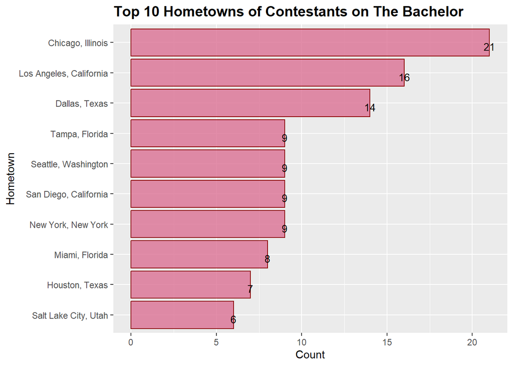

```r
Contestants %>%
  left_join(Hometown, by = c("hometown" = "city")) %>%
  group_by(hometown) %>%
  filter(show=="Bachelor") %>%
  summarise(count = n()) %>%
  arrange(desc(count)) %>%
  top_n(10) %>%
  ggplot(aes(x = reorder(hometown, count), y = count)) +
  geom_col(fill="palevioletred", color="darkred", alpha=0.8) +
  coord_flip() +
  labs(title = "Top 10 Hometowns of Contestants on The Bachelor",
       x = "Hometown",
       y = "Count")+
 theme(plot.title = element_text(size=14, face="bold"))+
  geom_text(aes(label=count), vjust=1, size=3.5)
```

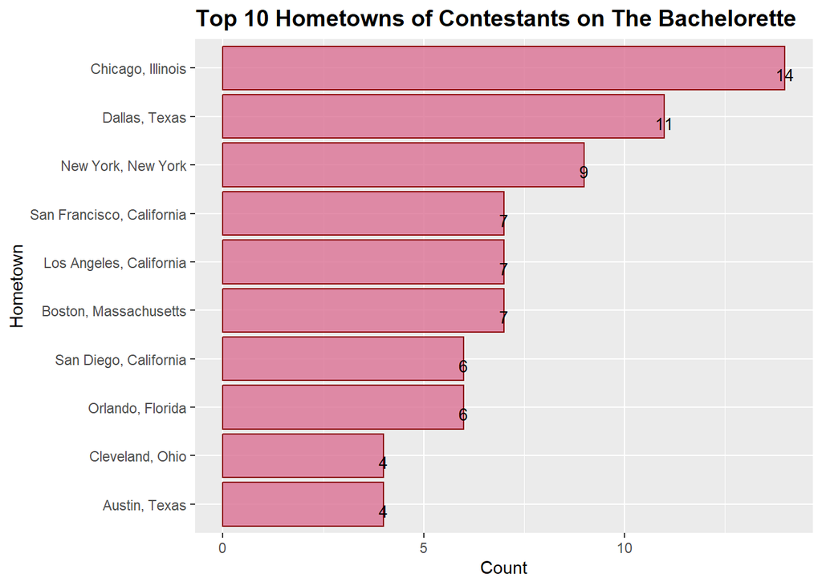

```r
Contestants %>%
  left_join(Hometown, by = c("hometown" = "city")) %>%
  group_by(hometown) %>%
  filter(show=="Bachelorette") %>%
  summarise(count = n()) %>%
  arrange(desc(count)) %>%
  top_n(10) %>%
  ggplot(aes(x = reorder(hometown, count), y = count)) +
  geom_col(fill="palevioletred", color="darkred", alpha=0.8) +
  coord_flip() +
  labs(title = "Top 10 Hometowns of Contestants on The Bachelorette",
       x = "Hometown",
       y = "Count")+
 theme(plot.title = element_text(size=14, face="bold"))+
  geom_text(aes(label=count), vjust=1, size=3.5)
```

```r
Contestants %>%
  left_join(Hometown, by = c("hometown" = "city")) %>%
  select(full_name, age, occupation, hometown)
```

```
##                         full_name age                                occupation
## 1                           Alexa  27                       Special Ed. Teacher
## 2                    Amanda Marsh  23                             Event Planner
## 3                           Amber  29             Business Development Director
## 4                             Amy  28                    Production Coordinator
## 5                          Angela  25                          Hooters Waitress
## 6                       Angelique  27                                   Actress
## 7                    Cathy Grimes  22                          Graduate Student
## 8                       Christina  28                                  Attorney
## 9                         Daniela  30                         Neuropsychologist
## 10                         Denise  30                                    Doctor
## 11                         Jackie  22                               Bar Manager
## 12                           Jill  31                            Retail Manager
## 13                          Katie  23                     Power Tool Sales Rep.
## 14                            Kim  24                                     Nanny
```

[output cut: 2191 more lines]

# make a map of the hometowns of the contestants

```r
register_stadiamaps("4e32b9b8-f5a9-4134-810b-1c546c2a9800", write = FALSE)
```

```r
Hometown %>%
  select(lat, long) %>%
  summary()
```

```
##       lat              long
##  Min.   :-34.60   Min.   :-157.83
##  1st Qu.: 34.07   1st Qu.:-106.10
##  Median : 39.37   Median : -87.79
##  Mean   : 38.05   Mean   : -87.14
##  3rd Qu.: 41.90   3rd Qu.: -79.08
##  Max.   : 61.21   Max.   : 123.33
```

```r
lat <- c(-34.60, 61.21)
long <- c(-157.83, 123.33)
bbox <- make_bbox(long, lat, f = 0.03)
```

```r
map1 <- get_stadiamap(bbox, maptype = "stamen_terrain", zoom=4)
```

```
## ℹ © Stadia Maps © Stamen Design © OpenMapTiles © OpenStreetMap contributors.
```

```
## ℹ 84 tiles needed, this may take a while (try a smaller zoom?)
```

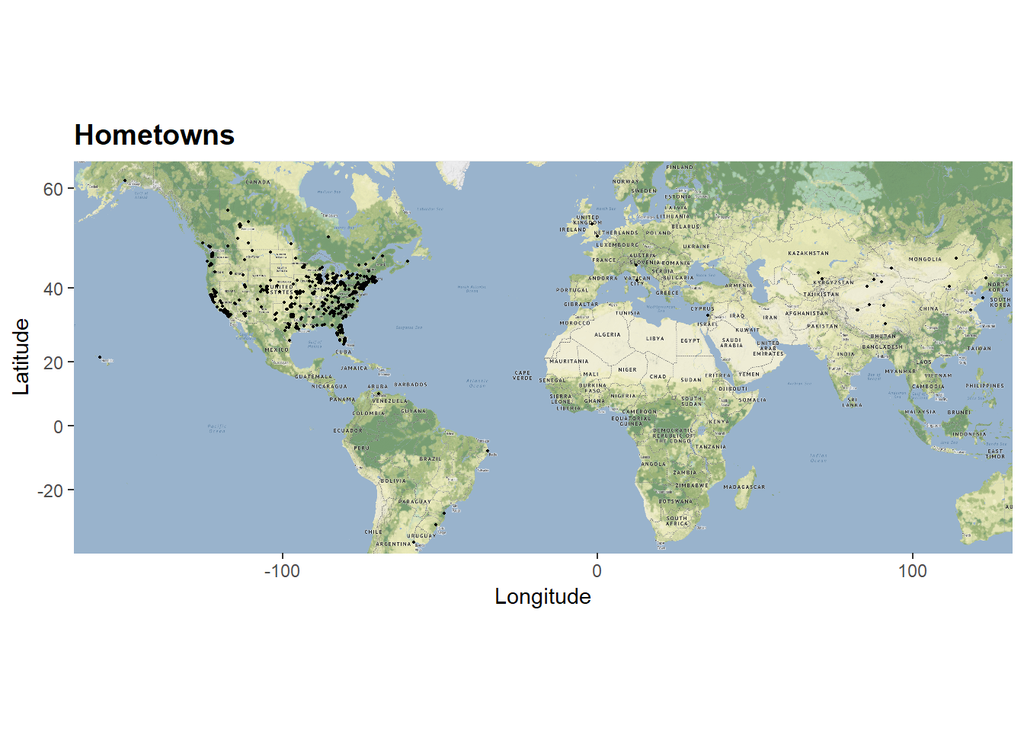

```r
ggmap(map1) +
  geom_point(data = Hometown, aes(long, lat), size=0.4)+
  labs(x="Longitude", y="Latitude", title= "Hometowns")+
  theme(plot.title = element_text(size=14, face="bold"))
```

# Im going to make a cleaner data set that combines the eliminations data with the contestants data so I can see who received a rose because i’m having trouble working with the full_names column and homerange. And there’s recorded data in the action column that i want to remove.

```r
states <- Contestants %>%
  left_join(Hometown, by = c("hometown" = "city")) %>%
  select(full_name, age, occupation, hometown, show) %>%
  separate(hometown, c("city", "state"), sep = ", ") %>%
  separate(full_name, c("first_name", "last_name"), sep = " ")
states
```

```
##          first_name      last_name age
## 1             Alexa           <NA>  27
## 2            Amanda          Marsh  23
## 3             Amber           <NA>  29
## 4               Amy           <NA>  28
## 5            Angela           <NA>  25
## 6         Angelique           <NA>  27
## 7             Cathy         Grimes  22
## 8         Christina           <NA>  28
## 9           Daniela           <NA>  30
## 10           Denise           <NA>  30
## 11           Jackie           <NA>  22
## 12             Jill           <NA>  31
## 13            Katie           <NA>  23
## 14              Kim           <NA>  24
```

[output cut: 3294 more lines]

```r
new_eliminations <- Eliminations %>%
  separate(full_name, c("first_name", "last_name"), sep = " ")
new
```

[output not shown]

#combine that states data with the new_eliminations data

```r
improved_data <- new_eliminations %>%
  left_join(states, by = c("first_name", "last_name")) %>%
  select(-unique_id)
improved_data
```

```
##            show.x season     first_name      last_name episode action age
## 1        Bachelor      1          Alexa           <NA>       2      E  27
## 2        Bachelor      1          Alexa           <NA>       2     D5  27
## 3        Bachelor      1         Amanda          Marsh       6      W  23
## 4        Bachelor      1         Amanda          Marsh       2     D5  23
## 5        Bachelor      1         Amanda          Marsh       3     D1  23
## 6        Bachelor      1         Amanda          Marsh       4     D1  23
## 7        Bachelor      1         Amanda          Marsh       5     D1  23
## 8        Bachelor      1         Amanda          Marsh       6     D1  23
## 9        Bachelor      1          Amber           <NA>       1      E  29
## 10       Bachelor      1          Amber           <NA>       1      E  26
## 11       Bachelor      1          Amber           <NA>       1      E  23
## 12       Bachelor      1            Amy           <NA>       2      E  28
## 13       Bachelor      1            Amy           <NA>       2      E  27
## 14       Bachelor      1            Amy           <NA>       2      E  22
```

[output cut: 10638 more lines]

#Names with the most wins

```r
improved_dataW <- improved_data %>%
  filter(action == c("W")) %>%
  select(-show.y)
```

```r
improved_dataW %>%
  group_by(first_name) %>%
  filter(show.x=="Bachelor") %>%
  summarise(count = n()) %>%
  arrange(desc(count))
```

```
## # A tibble: 20 × 2
##    first_name count
##    <chr>      <int>
##  1 Mary           2
##  2 Sarah          2
##  3 Amanda         1
##  4 Catherine      1
##  5 Courtney       1
##  6 Emily          1
##  7 Estella        1
##  8 Helene         1
##  9 Jen            1
## 10 Jennifer       1
## 11 Jessica        1
## 12 Lauren         1
## 13 Melissa        1
## 14 Nikki          1
## 15 Rebecca        1
## 16 Shayne         1
## 17 Tessa          1
## 18 Vanessa        1
## 19 Vienna         1
## 20 Whitney        1
```

# made data set with only the roses given out

```r
improved_data1 <- improved_data %>%
  filter(action == c("R1", "R")) %>%
  select(-show.y)
improved_data1
```

```
##           show.x season first_name   last_name episode action age
## 1   Bachelorette      3      Keith        <NA>       1     R1  31
## 2   Bachelorette      4     Graham        Bunn       2      R  29
## 3   Bachelorette      4      Jason     Mesnick       3      R  31
## 4   Bachelorette      4      Jesse    Csincsak       1     R1  26
## 5   Bachelorette      4      Jesse    Csincsak       4      R  26
## 6   Bachelorette      4    Richard       Mathy       1     R1  27
## 7       Bachelor      5      Trish   Schneider       1     R1  28
## 8   Bachelorette      5         Ed   Swiderski       3      R  29
## 9   Bachelorette      5      Jesse      Kovacs       5      R  27
## 10  Bachelorette      5       Juan    Barbieri       2      R  35
## 11  Bachelorette      5     Kiptyn       Locke       4      R  31
## 12  Bachelorette      5       Reid   Rosenthal       6      R  30
## 13  Bachelorette      6      Frank Neuschaefer       6      R  31
## 14  Bachelorette      6       Kirk     DeWindt       3      R  27
```

[output cut: 528 more lines]

#show the number of roses given out between the bachelor and bachelorette

```r
improved_data1 %>%
  filter(show.x=="Bachelorette") %>%
  summarise(count = n()) %>%
  arrange(desc(count))
```

```
##   count
## 1    77
```

```r
improved_data1 %>%
  filter(show.x=="Bachelor") %>%
  summarise(count = n()) %>%
  arrange(desc(count))
```

```
##   count
## 1   103
```

```r
improved_data1 %>%
  group_by(first_name) %>%
  filter(show.x=="Bachelorette") %>%
  summarise(count = n()) %>%
  arrange(desc(count))
```

```
## # A tibble: 49 × 2
##    first_name count
##    <chr>      <int>
##  1 Nick           7
##  2 Ben            6
##  3 Chris          4
##  4 Bryan          3
##  5 Jesse          3
##  6 Bryden         2
##  7 Dean           2
##  8 Eric           2
##  9 James          2
## 10 Jef            2
## # ℹ 39 more rows
```

##make a bar graph with the improved_data that the shows that most popular names of the contestants

```r
improved_data1 %>%
  group_by(show.x) %>%
  summarise(mean_age = mean(age, na.rm = TRUE))
```

```
## # A tibble: 2 × 2
##   show.x       mean_age
##   <chr>           <dbl>
## 1 Bachelor         26.3
## 2 Bachelorette     29.3
```

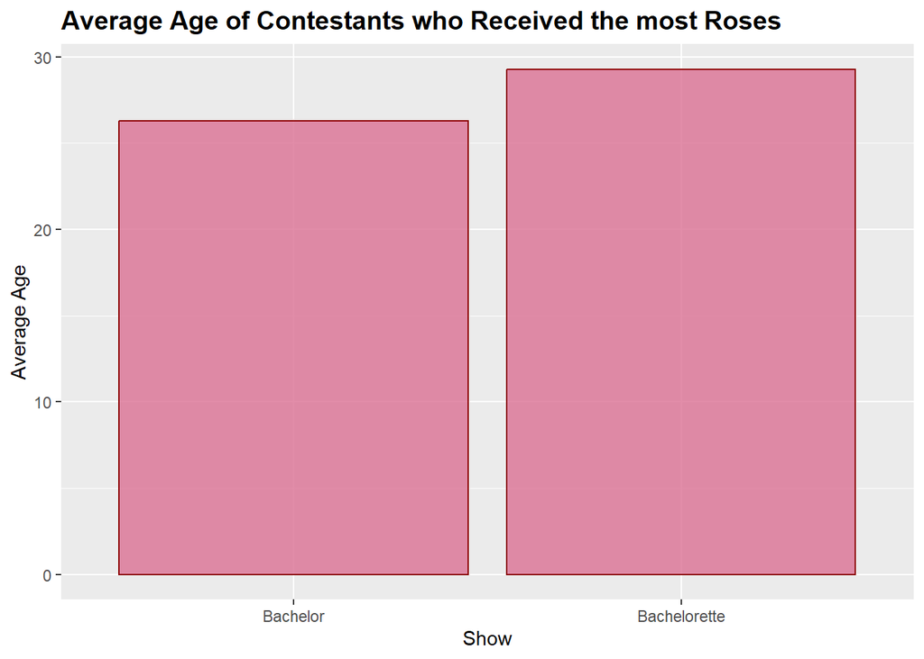

```r
improved_data1 %>%
  group_by(show.x) %>%
  summarise(mean_age = mean(age, na.rm = TRUE)) %>%
  ggplot(aes(x = show.x, y = mean_age, fill = show)) +
  geom_col(fill="palevioletred", color="darkred", alpha=0.8) +
  labs(title = "Average Age of Contestants who Received the most Roses",
       x = "Show",
       y = "Average Age",
       fill = "Show")+
  theme(plot.title = element_text(size=14, face="bold"))
```

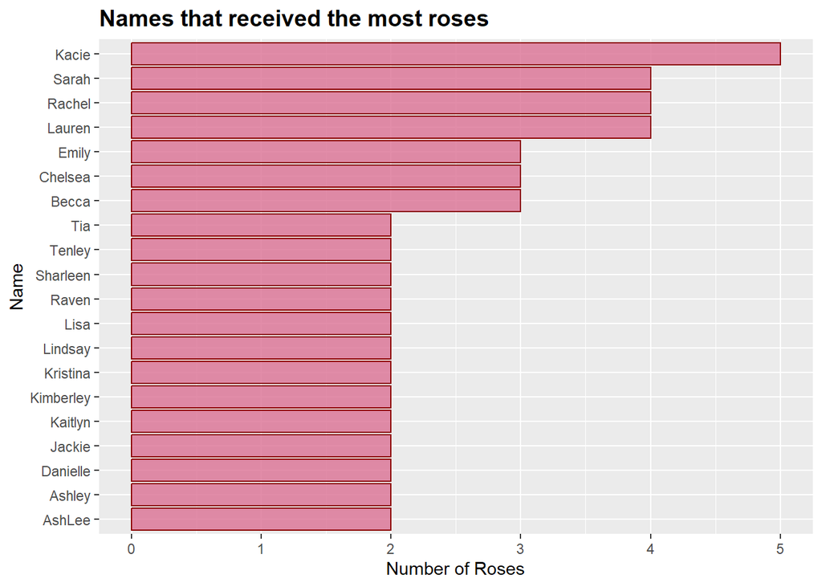

```r
improved_data1 %>%
  group_by(first_name) %>%
  filter(show.x=="Bachelor") %>%
  summarise(count = n()) %>%
  arrange(desc(count)) %>%
  top_n(10) %>%
  ggplot(aes(x = reorder(first_name, count), y = count)) +
  geom_col(fill="palevioletred", color="darkred", alpha=0.8) +
  coord_flip() +
  labs(title = "Names that received the most roses",
       x = "Name",
       y = "Number of Roses")+
 theme(plot.title = element_text(size=14, face="bold"))
```

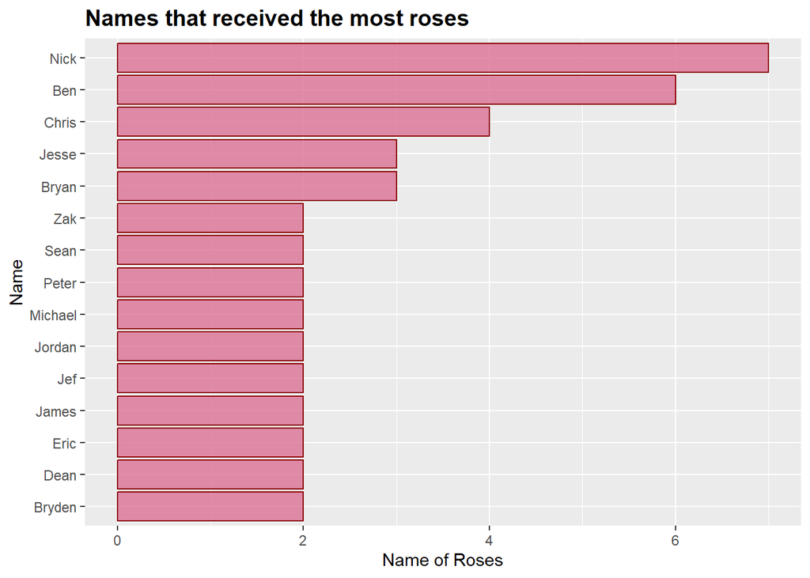

```r
improved_data1 %>%
  group_by(first_name) %>%
  filter(show.x=="Bachelorette") %>%
  summarise(count = n()) %>%
  arrange(desc(count)) %>%
  top_n(10) %>%
  ggplot(aes(x = reorder(first_name, count), y = count)) +
  geom_col(fill="palevioletred", color="darkred", alpha=0.8) +
  coord_flip() +
  labs(title = "Names that received the most roses",
       x = "Name",
       y = "Name of Roses")+
 theme(plot.title = element_text(size=14, face="bold"))
```

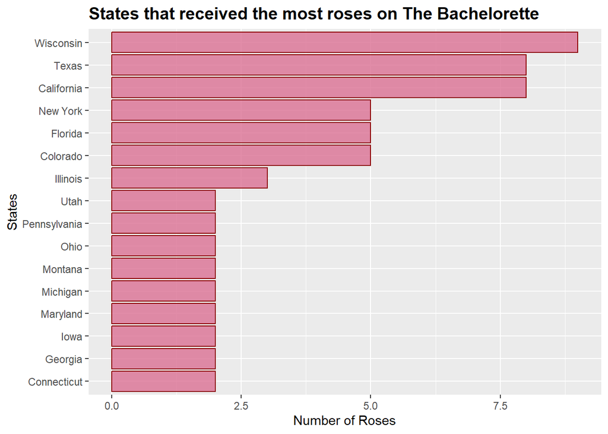

```r
improved_data1 %>%
  filter(!is.na(state)) %>%
  group_by(state) %>%
  filter(show.x=="Bachelorette") %>%
  summarise(count = n()) %>%
  arrange(desc(count)) %>%
  top_n(10) %>%
  ggplot(aes(x = reorder(state, count), y = count)) +
  geom_col(fill="palevioletred", color="darkred", alpha=0.8) +
  coord_flip() +
  labs(title = "States that received the most roses on The Bachelorette",
       x = "States",
       y = "Number of Roses")+
 theme(plot.title = element_text(size=14, face="bold"))
```

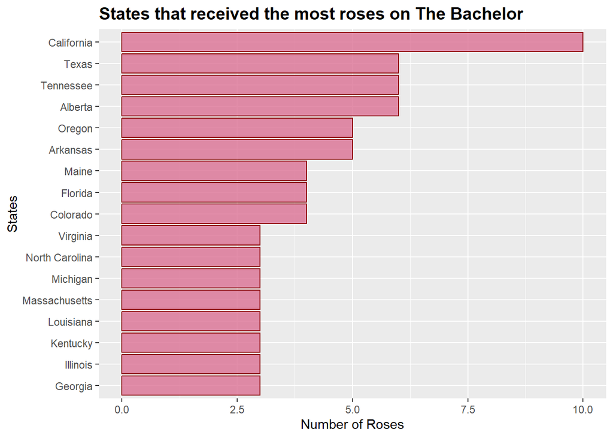

```r
improved_data1 %>%
  filter(!is.na(state)) %>%
  group_by(state) %>%
  filter(show.x=="Bachelor") %>%
  summarise(count = n()) %>%
  arrange(desc(count)) %>%
  top_n(10) %>%
  ggplot(aes(x = reorder(state, count), y = count)) +
  geom_col(fill="palevioletred", color="darkred", alpha=0.8) +
  coord_flip() +
  labs(title = "States that received the most roses on The Bachelor",
       x = "States",
       y = "Number of Roses")+
 theme(plot.title = element_text(size=14, face="bold"))
```

##

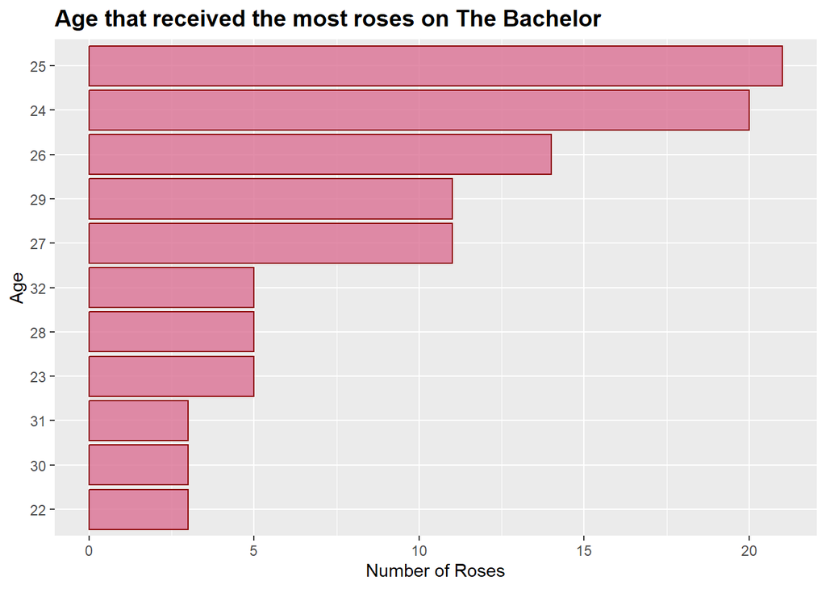

```r
improved_data1 %>%
  filter(!is.na(age)) %>%
  group_by(age) %>%
  filter(show.x=="Bachelor") %>%
  summarise(count = n()) %>%
  arrange(desc(count)) %>%
  top_n(10) %>%
  ggplot(aes(x = reorder(age, count), y = count)) +
  geom_col(fill="palevioletred", color="darkred", alpha=0.8) +
  coord_flip() +
  labs(title = "Age that received the most roses on The Bachelor",
       x = "Age",
       y = "Number of Roses")+
 theme(plot.title = element_text(size=14, face="bold"))
```

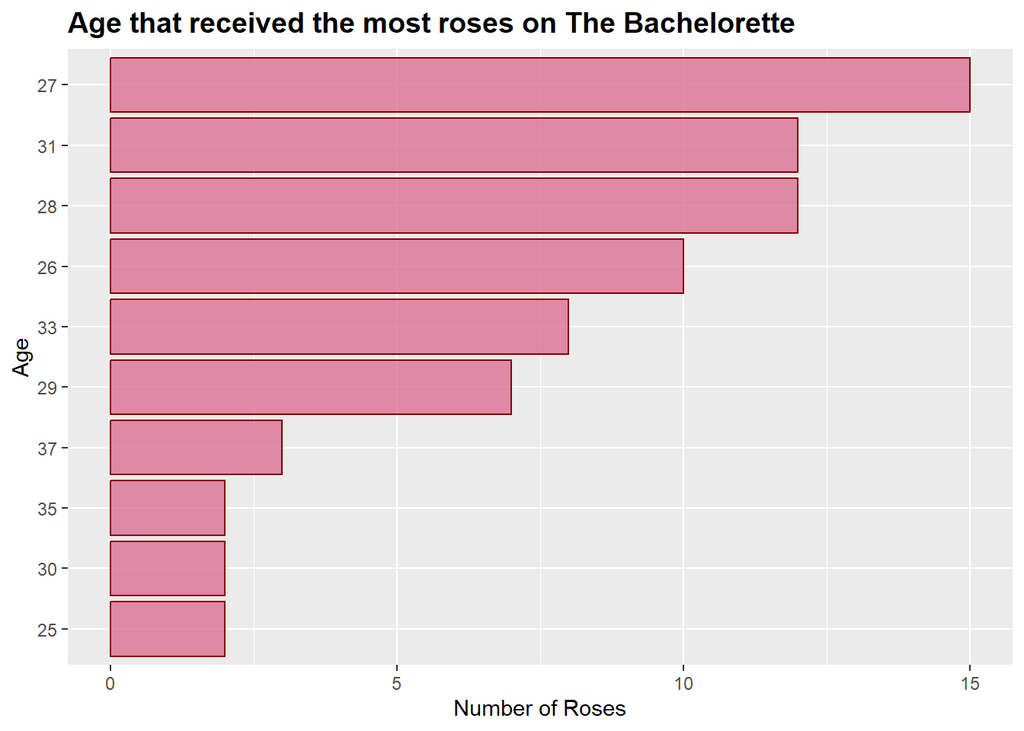

```r
improved_data1 %>%
  filter(!is.na(age)) %>%
  group_by(age) %>%
  filter(show.x=="Bachelorette") %>%
  summarise(count = n()) %>%
  arrange(desc(count)) %>%
  top_n(10) %>%
  ggplot(aes(x = reorder(age, count), y = count)) +
  geom_col(fill="palevioletred", color="darkred", alpha=0.8) +
  coord_flip() +
  labs(title = "Age that received the most roses on The Bachelorette",
       x = "Age",
       y = "Number of Roses")+
 theme(plot.title = element_text(size=14, face="bold"))
```

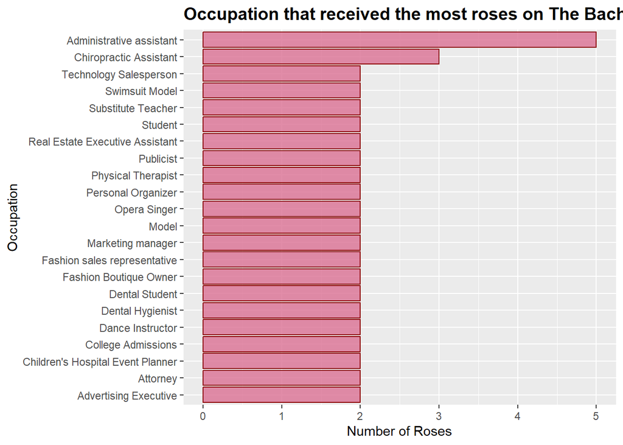

```r
improved_data1 %>%
  filter(!is.na(occupation)) %>%
  group_by(occupation) %>%
  filter(show.x=="Bachelor") %>%
  summarise(count = n()) %>%
  arrange(desc(count)) %>%
  top_n(10) %>%
  ggplot(aes(x = reorder(occupation, count), y = count)) +
  geom_col(fill="palevioletred", color="darkred", alpha=0.8) +
  coord_flip() +
  labs(title = "Occupation that received the most roses on The Bachelor",
       x = "Occupation",
       y = "Number of Roses")+
 theme(plot.title = element_text(size=14, face="bold"))
```

##

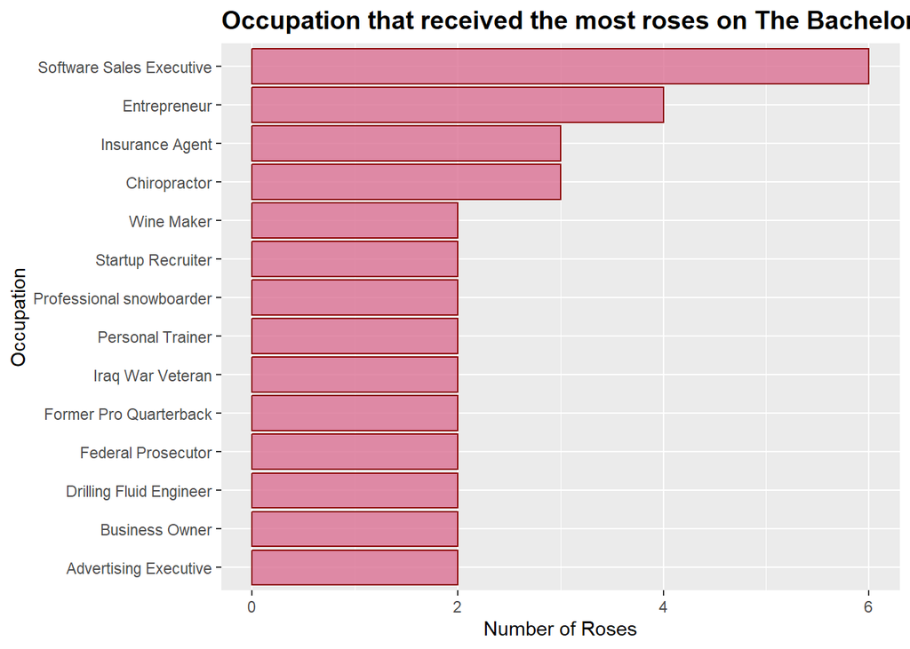

```r
improved_data1 %>%
  filter(!is.na(occupation)) %>%
  group_by(occupation) %>%
  filter(show.x=="Bachelorette") %>%
  summarise(count = n()) %>%
  arrange(desc(count)) %>%
  top_n(10) %>%
  ggplot(aes(x = reorder(occupation, count), y = count)) +
  geom_col(position="dodge", fill="palevioletred", color="darkred", alpha=0.8) +
  coord_flip() +
  labs(title = "Occupation that received the most roses on The Bachelorette",
       x = "Occupation",
       y = "Number of Roses")+
 theme(plot.title = element_text(size=14, face="bold"))
```

make a plot that shows which occupation received the most roses

```r
Eliminations %>%
  mutate(first_impression_rose = ifelse(action == "R1", "Yes", "No")) %>%
  group_by(first_impression_rose) %>%
  filter(first_impression_rose == "Yes") %>%
  filter(show=="Bachelor") %>%
  count()
```

```
## # A tibble: 1 × 2
## # Groups:   first_impression_rose [1]
##   first_impression_rose     n
##   <chr>                 <int>
## 1 Yes                      28
```

```r
Eliminations %>%
  mutate(first_impression_rose = ifelse(action == "R1", "Yes", "No")) %>%
  group_by(first_impression_rose) %>%
  filter(first_impression_rose == "Yes") %>%
  filter(show=="Bachelorette") %>%
  count()
```

```
## # A tibble: 1 × 2
## # Groups:   first_impression_rose [1]
##   first_impression_rose     n
##   <chr>                 <int>
## 1 Yes                      18
```

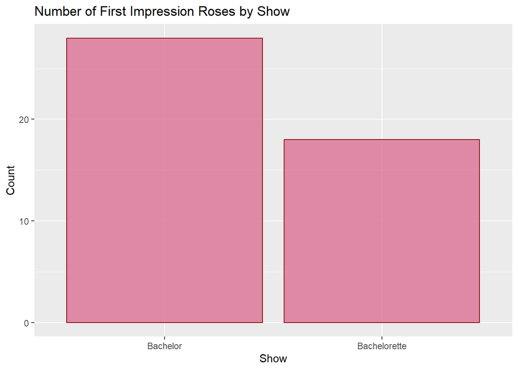

```r
Eliminations %>%
  mutate(first_impression_rose = ifelse(action == "R1", "Yes", "No")) %>%
  group_by(show, first_impression_rose) %>%
  filter(first_impression_rose == "Yes") %>%
  summarise(count = n()) %>%
  ggplot(aes(x = show, y = count, fill = show)) +
  geom_col(fill="palevioletred", color="darkred", alpha=0.8) +
  labs(title = "Number of First Impression Roses by Show",
       x = "Show",
       y = "Count",
       fill = "Show")
```

```r
first_impression_rose <- Eliminations %>%
  mutate(first_impression_rose = ifelse(action == "R1", "Yes", "No")) %>%
  filter(first_impression_rose == "Yes")
first_impression_rose
```

```
##            show season      unique_id              full_name episode action
## 1  Bachelorette      3       03_KEITH                  Keith       1     R1
## 2  Bachelorette      4    04_JEREMY_A        Jeremy Anderson       1     R1
## 3  Bachelorette      4     04_JESSE_C         Jesse Csincsak       1     R1
## 4  Bachelorette      4   04_RICHARD_M          Richard Mathy       1     R1
## 5      Bachelor      5     05_TRISH_S        Trish Schneider       1     R1
## 6  Bachelorette      5     05_DAVID_G             David Good       1     R1
## 7  Bachelorette      6    06_ROBERT_M       Roberto Martinez       1     R1
## 8      Bachelor      7       07_KERRY                  Kerry       1     R1
## 9      Bachelor      7    07_SARAH W.               Sarah W.       1     R1
## 10 Bachelorette      7      07_RYAN_P              Ryan Park       1     R1
## 11 Bachelorette      8      08_DOUG_C           Doug Clerget       1     R1
## 12     Bachelor      9      09_LISA_B             Lisa Blank       1     R1
## 13 Bachelorette      9       09_BEN_S              Ben Scott       1     R1
## 14 Bachelorette      9    09_BRYDEN_V         Bryden Vukasin       1     R1
```

[output cut: 79 more lines]

##using the Seasons dataset make a graph that compares the number of proposals on the bachelor and bachelorette

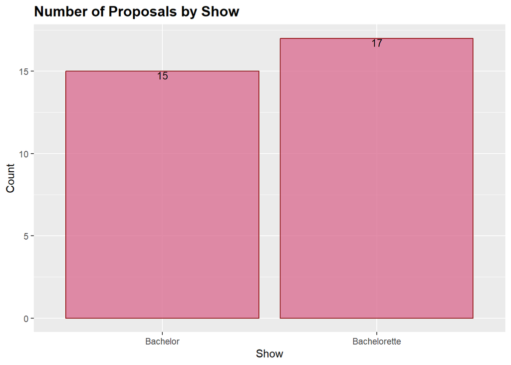

```r
Seasons %>%
  group_by(show) %>%
  filter(proposal=="TRUE") %>%
  summarise(count = n()) %>%
  ggplot(aes(x = show, y = count, fill = show)) +
  geom_col(fill="palevioletred", color="darkred", alpha=0.8) +
  labs(title = "Number of Proposals by Show",
       x = "Show",
       y = "Count",
       fill = "Show")+
  theme(plot.title = element_text(size=14, face="bold"))+
  geom_text(aes(label=count), vjust=1, size=3.5)
```